# OPENFLEX: benchmark reproduction and current Leeds amplification

Published

October 3, 2026

## Continuation and timing correction

This is the first diagnostic block record. The completed bounded decision is in `qmd/reports/2026-10-03-openflex-decision.qmd`, with full-state pulse audits, directional Jacobian checks, the rejected depth screen and alternative-closure mapping. Statements below about tasks still open or selected observations describe that earlier block. Spending is restored at t10, but the final counter-input is also at t10: **t11 is the first fully unforced period**. The corrected t20/t11 amplification is about 2.10; the earlier 2.26 ratio uses t10. No Leeds stabilization is claimed.

## Finding and status

**The supplied OPENFLEX_S equations provide a numerical positive control. The current Leeds OPENFLEX remains an excluded diagnostic.** Both independent benchmark solvers complete the supplied baseline and a temporary export experiment through 2100 with positive wealth/prices/quotes and nonnegative recorded financial holdings. The benchmark’s quote grows only 0.000204% per period over its t70–100 tail. Current Leeds instead amplifies small government expenditure disturbances after spending has returned to baseline.

This completes investigation-plan Tasks 1–2 and advances Task 3. It does not establish a stabilized Leeds calibration, native EViews agreement, a complete accounting matrix, a constrained transition spectrum or a minimal causal loop. Tasks 4–6 remain open. No stabilization candidate or alternative institutional closure has been run, and the two-session stopping checkpoint has not been invoked. Four-closure review remains independent.

## Frozen objects and acceptance contract

The saved input manifest validates both supplied reference files, all 21 retained launch sources and current Leeds cache `80dc540620c1ddd971c2c4a68fa3a95959140518445521ef9dba6789ae257471`. The protected manifest covers 200 files, including all 104 accepted caches, canonical sources/generated engines, workbooks and manuscript sources. Its post-experiment validation reports no protected byte changes. Manuscript contents are not copied into the experiment outputs.

The numerical gate is a maximum scaled residual below 1e-9; the named accounting gate is 1e-8 with absolute, level and own-VA residuals reported separately. A candidate baseline must complete t100, retain positive quotes, prices and household wealth, and nonnegative applicable holdings. Signed advances may represent documented bank reserve deposits. The t70–100 quote growth ceiling is 0.1% per period, with explicit quote/CAB ranges and stock drift. The attraction gate uses both signs and two sizes of a one-period t70 disturbance, comparing t100 with the first unforced observation; one t150 extension is allowed. Early t9–20 probes below are diagnosis, not that gate.

Exact thresholds, naming, failure retention and experiment limits are in `output/calibration/openflex_attack/experiment_contract.json`.

## Independent benchmark port

All 92 active assignments map to 92 distinct executable unknowns. Initial values, parameters, current inputs, lagged inputs and translated expressions are written separately. No required current input or presample lag is missing. Four initialized series are unused: cash-demand series `h_A_d`, `h_B_d` and expected quotes `xre_A`, `xre_B`. Baseline pass-through remains `nu1m=0.7` and `nu1x=0.5`; foreign-bill demand intercept remains 0.25.

The port preserves case-insensitive names, `d(x)=x(t)-x(t-1)`, lagged relative trade prices, current foreign output, income averaging and nominal wealth with one currency-gain term. Translation fixtures check differences, lags and log/exp. Both 1950 and 1951 carry the authored rounded initial values. Solves start in 1952, correcting the source shock harness’s `smpl @all` reset without changing economic equations.

The temporary fixture adds 0.01 to the export intercept `eps0` in 2020–2024 and removes it in 2025. It is a finite disturbance designed for this investigation, not an asserted original published scenario. Independent simultaneous Powell-hybrid root solves and authored-order Gauss–Seidel each propagate their own states, without cached trajectory guesses.

| Method | Experiment | Last | Residual | Positive | Holdings |
| --- | --- | --- | --- | --- | --- |
| hybr | Baseline | 2100 | 9.25688e-13 | TRUE | TRUE |
| hybr | Temporary export | 2100 | 9.25688e-13 | TRUE | TRUE |
| gauss | Baseline | 2100 | 9.99588e-11 | TRUE | TRUE |
| gauss | Temporary export | 2100 | 9.99588e-11 | TRUE | TRUE |

| Experiment | Years | Difference |
| --- | --- | --- |
| baseline | 149 | 5.98406e-10 |
| temporary_export | 149 | 4.13086e-10 |

The largest scaled method difference is below 6e-10. A centered numerical within-period residual Jacobian at baseline 2100 has rank 92 at relative singular-value threshold 1e-10, with condition number about 43,065. This is a local finite-difference measurement; assignment count, local rank and small residuals imply neither global uniqueness nor dynamic attraction.

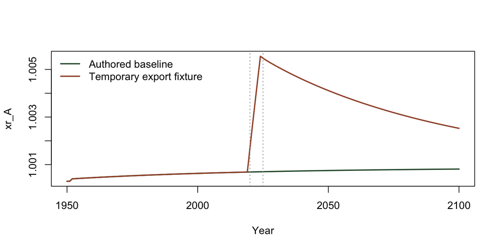

Supplied benchmark: authored baseline and the isolated temporary export fixture. The fixture ends in 2024.

The quote and both current-account differences shrink between the first unforced year and 2100, but household wealth differences reverse sign and remain larger in absolute value. This one positive disturbance does not pass the signed/two-size componentwise attraction contract.

| Variable | Difference2025 | Difference2100 | Ratio |
| --- | --- | --- | --- |
| xr_a | 0.00477212 | 0.00171337 | 0.359037 |
| cab_a | -0.0200221 | -0.0013706 | 0.0684545 |
| cab_b | 0.020131 | 0.00137398 | 0.0682518 |
| v_a | 0.0276037 | -0.0439602 | 1.59254 |
| v_b | -0.0344296 | 0.0368194 | 1.06941 |

### Accounting qualification

The supplied rounded presample already violates household portfolio and bill identities. These numerical inputs were preserved, not silently reconciled. The cash/Haig–Simons distinction, wealth changes, household portfolio sums, cash balances, CB balance-sheet changes, reciprocal quotes and B bill market pass after solving. The first solved year’s balance-of-payments discrepancy is about 0.004914; after that it falls to numerical precision. The source capital account is inward financial flow, so its identity is **CAB + KAB=0**.

The redundant A bill residual remains nonzero and grows at its 3% bill rate: `E(t)=(1+r_A(t-1))E(t-1)` after the first solve. Its innovation is below 1.63834e-12 thereafter; at 2100 its absolute level is approximately 0.001543. This is distinct from quote growth and prevents a full accounting-pass claim for the untouched rounded initialization.

| country | check | residual |
| --- | --- | --- |
| a | household_portfolio | -0.00211384 |
| a | bill_market | -0.00684000 |
| b | household_portfolio | 0.00256390 |
| b | bill_market | 0.00726000 |

| Region | Identity | Absolute | Scaled | From1953 |
| --- | --- | --- | --- | --- |
| A | cash income | 2.84217e-14 | 3.76065e-16 | 3.76065e-16 |
| A | haig simons once | 2.84217e-14 | 3.76058e-16 | 3.76058e-16 |
| A | wealth change | 4.26326e-14 | 4.26326e-14 | 4.26326e-14 |
| A | household portfolio | 9.09495e-13 | 6.31381e-15 | 6.31381e-15 |
| A | cash supply | 0 | 0 | 0 |
| A | bill market | 0.00154317 | 1.14587e-05 | 1.14587e-05 |
| A | balance of payments | 0.00491193 | 0.00491193 | 3.07714e-12 |
| A | cb cash change | 1.15186e-15 | 1.15186e-15 | 1.15186e-15 |
| B | cash income | 4.26326e-14 | 5.63854e-16 | 5.63854e-16 |
| B | haig simons once | 2.84217e-14 | 3.75953e-16 | 3.75953e-16 |
| B | wealth change | 5.68434e-14 | 5.68434e-14 | 5.68434e-14 |
| B | household portfolio | 9.37916e-13 | 6.50995e-15 | 6.50995e-15 |
| B | cash supply | 0 | 0 | 0 |
| B | bill market | 5.68434e-14 | 4.21419e-16 | 4.21419e-16 |
| B | balance of payments | 0.0049139 | 0.0049139 | 3.0672e-12 |
| B | cb cash change | 1.08247e-15 | 1.08247e-15 | 1.08247e-15 |
| A | reciprocal quotes | 6.66134e-16 | 6.66134e-16 | 6.66134e-16 |

Native EViews is absent; author output fixtures are not supplied. The port is an independent numerical reproduction of supplied assignments, with stated accounting failures. It is not certified EViews or published-output agreement. OPENECO requires the missing `data_seps.xls` and import layout. No alternative native reproduction or stable literature preset is claimed.

## Current Leeds accounting and tighter roots

The financial ledger maps cash, deposits, household and firm loans, advances, bills and equity for households, firms, banks, governments and central banks in both regions. Instrument entries are in a common Z1 currency. Stock changes are split into transactions at the current quote and valuation of the previous stock. Foreign bills/equity use issuer-currency holdings; domestic equity uses the household `e_h` row rather than the unused domestic `e_s_Zz` row. The selected one-sided CB reserve closure has no mirror reserve row; that absent holding is explicitly structural zero.

All 24 selected source-identity constraints pass after the initial observation. The independent instrument ledger retains the redundant EU bill residual. Transaction/valuation decomposition closes to 7.4e-13. CB foreign-reserve valuation changes its net worth; it is not an extra household income gain. The ledger does **not** yet independently audit real capital/sector net worth or the full goods, wages, taxes, dividend and interest transaction-flow matrix.

Tighter solves retain the verified launch equations, both reciprocal quotes, the financial stocks and technology. A minimum 130 settlement sweeps eliminates inner stopping jitter before applying the quote gap threshold 1e-12. The unperturbed t10/t20 roots match the cache within 6e-12. Tightening the final inner tolerance from 1e-8 to 1e-10 leaves the solutions unchanged at the shown precision. Cached close guesses are used; robust independent initialization is not established.

| Period | Tolerance | Difference | Step | Gap | BillResidual |
| --- | --- | --- | --- | --- | --- |
| 10 | 1e-08 | 5.29354e-12 | 0 | 2.88658e-15 | -3.00799e-07 |
| 10 | 1e-10 | 5.29354e-12 | 0 | 2.88658e-15 | -3.00799e-07 |
| 20 | 1e-08 | 4.86011e-12 | 0 | 6.66134e-16 | -3.72429e-07 |
| 20 | 1e-10 | 4.86011e-12 | 0 | 6.66134e-16 | -3.72429e-07 |

The EU bill error starts at −2.55e-7 in t2 and subsequently accumulates at about 2.159% per period. After t2 the maximum error innovation is 1.46136e-09. Re-solving t10/t20 with cached lags retains the inherited error. It does not explain the current quote’s 14.6173% ordinary deviation growth over t5–100. Current-cache first negative EU CB bills remain t56 and RoW household own bills t84.

## Current Leeds quote partials and temporary disturbances

Centered fixed-quote partials at sizes 1e-4 and 1e-5 agree closely at t10/t20. The clearing-gap derivative is −2.305 at t10 and −2.176 at t20. These are within-period derivatives, not solved-state transition eigenvalues.

| Period | Step | Hq | SupplyElasticity | DemandElasticity | dV1 | dV2 |
| --- | --- | --- | --- | --- | --- | --- |
| 10 | 0.0001 | -2.30474 | -1.3791 | -0.0743586 | -144.51 | 218.033 |
| 10 | 1e-05 | -2.30474 | -1.3791 | -0.0743586 | -144.51 | 218.033 |
| 20 | 0.0001 | -2.17589 | -1.24739 | -0.0714979 | -112.612 | 191.206 |
| 20 | 1e-05 | -2.17589 | -1.24739 | -0.0714979 | -112.612 | 191.206 |

At fixed lagged states, a higher quote lowers EU wealth and holder demand for foreign bills. That is a candidate positive quote–wealth–demand leg. However, residual foreign-bill supply falls more strongly, so the net contemporaneous ratio feedback has the opposite sign. The thin-market ratio alone is not a causal account of the dynamic instability. Identifying the delayed loop needs a constrained solved-state transition audit and accounting-preserving channel probes. No earlier old-calibration eigenvalue is transferred to this cache.

The early temporary fixture changes EU real government spending at t9 and removes its carried increment at t10. Both signs and sizes 1e-4 and 1e-5 are tested. Each branch propagates all solved states and technology. Its control branch is re-solved under the same tighter tolerance, avoiding accumulated cache-precision differences in tiny responses.

| Size | Response10 | Response20 | Ratio | Reset | MinBills | Reciprocity |
| --- | --- | --- | --- | --- | --- | --- |
| -0.0001 | -0.00238114 | -0.00538781 | 2.2627 | 0 | 63.4848 | 1.11022e-16 |
| -1e-05 | -0.00238109 | -0.00538755 | 2.26264 | 0 | 63.4855 | 2.22045e-16 |
| 1e-05 | -0.00238108 | -0.0053875 | 2.26262 | 0 | 63.4857 | 2.22045e-16 |
| 0.0001 | -0.00238103 | -0.00538724 | 2.26256 | 0 | 63.4865 | 1.11022e-16 |

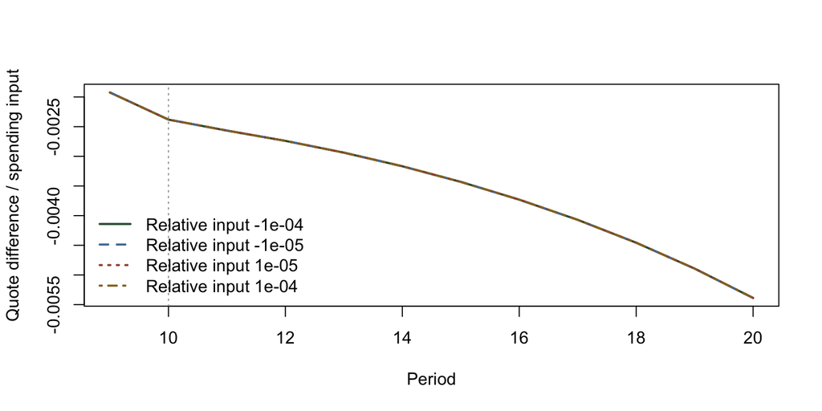

Leeds: quote differences per unit of temporary EU spending, relative to a re-solved control. Spending is restored at t10; deviations amplify through t20.

The signs and sizes give similar amplification, so the effect survives a directional precision check. Recorded bill holdings remain positive and quote reciprocity closes. The branches retain only selected observations; they do not yet certify every named accounting identity or every financial holding throughout the disturbance. These are early diagnostic pulses, not a t70 attraction test or a constrained transition spectrum.

## Remaining investigation and reproduction

1. Extend the disturbance receipts to retain full states and audit every instrument/holding and the real/financial transaction-flow matrix.
2. Separate the full within-period residual Jacobian from the constrained solved-state transition; identify justified candidate channels on the current cache before bounded calibration or behavioural tests.
3. Compare deeper portfolio demand and income smoothing with the benchmark without assuming either stabilizes Leeds. Any candidate remains isolated.
4. Deliver the reporting decision at the two-session checkpoint, with a negative or inconclusive result if justified. Keep four-closure review moving.

Run commands and source qualifications are in `R/dynamics/openflex_benchmark/README.md`. The live plan is `qmd/plans/2026-10-03-openflex-benchmark-and-stabilization.md`. All raw mappings, trajectories, solver residuals, named accounting failures, constraint ledgers and signed-pulse receipts are under `output/calibration/openflex_attack/`.

New harness failures were retained rather than interpreted as model failures: the first Python state merge, the superseded wrong-sign BOP audit, and two Leeds control harness attempts (a function name shadowed base R’s matrix solver; then inner stopping jitter prevented strict quote clearing). Corrected numerical runs are `benchmark/run_02`, `controls_03` and `pulses_01`. Canonical equations, calibration, workbooks, accepted caches and manuscript sources remain protected.